# Práctica 2. Tipologia de Datos. Limpieza y Visualización_2

Nuria García y Alicia Perdices

28 de mayo, 2020

#### **Inspección de Datos**

##### *1.-Carga de datos*

```r
data<-read.csv2("C:/temp/kidney_disease.csv",sep=",")
names<-colnames(data)
#Variables cualitativas
idQualitative <- which(names=="sg"| names=="al" | names=="su"| names=="rbc" | names=="pc" | names=="pcc" | names=="ba" | names=="htn" | names=="dm" | names=="cad"  | names=="appet" | names=="pe" | names=="ane"| names=="classification"  )

idQuantitative <- which(names=="age"| names=="bp" | names=="bgr"| names=="bu" | names=="sc" | names=="sod" | names=="pot" | names=="hemo" | names=="pcv" | names=="wc"  | names=="rc")
```

##### *2.Imputación de las variables numéricas con los tres vecinos más cercanos.*

**Transformación de variables**

- **age**

```r
data$age<-as.character(data$age)#Conversion a caracter
data$age<-as.numeric(gsub(",",".",data$age))#Se corrige posibles inconsistencias en el separador decimal y se tranforma en numeric.
data$age<-as.integer(data$age)#Se transforma a entero
#Comprobemos si hay nulos
table(is.na(data$age))
```

```
##
## FALSE  TRUE
##   391     9
```

```r
#Eliminamos nas del dataframe
data_nonas_age<-data[!is.na(data$age),]
#data_nonas_age$age

#Reemplazamos 'nas' del dataframe por la media del atributo age.
#Media de la columna age. A cada valor NA le asignamos la media de los valores de este atributo.
media_age<-mean(data_nonas_age$age)

data$age[is.na(data$age)]<-trunc(media_age)
table(is.na(data$age))
```

```
##
## FALSE
##   400
```

- **bp**

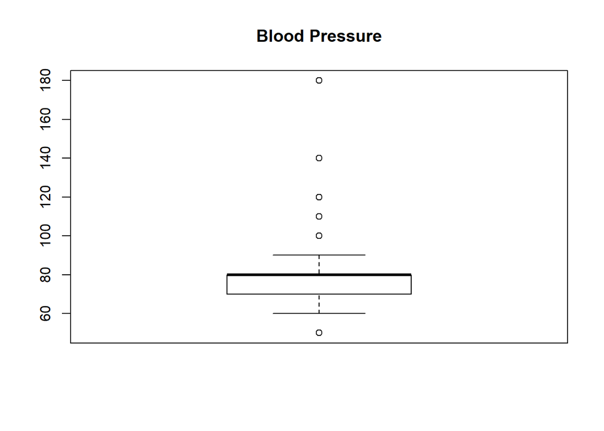

```r
#Blood Pressure
#===============

data$bp<-as.character(data$bp)#Conversion a caracter
data$bp<-as.numeric(gsub(",",".",data$bp))#Se corrige posibles inconsistencias en el separador decimal y se tranforma en numeric.
id_bp<-which(is.na(data$bp))
data[id_bp,]$bp<-NA
boxplot(data$bp,main='Blood Pressure')
```

- **sg**

```r
#Sustituimos los valores vacíos por la categoría más frecuente

frecuencias <- data.frame(table(data$sg))
moda <- frecuencias[which.max(frecuencias$Freq),1]

data$sg[data$sg=='']<-moda
```

- **al**

```r
#Sustituimos los valores vacíos por la categoría más frecuente

frecuencias2 <- data.frame(table(data$al))
moda2 <- frecuencias2[which.max(frecuencias2$Freq),1]

data$al[data$al=='']<-moda2
```

```r
#Sustituimos los valores vacíos por la categoría más frecuente

frecuencias4 <- data.frame(table(data$rbc))
moda4 <- frecuencias4[which.max(frecuencias4$Freq),1]

data$rbc[data$rbc=='']<-moda4
```

- **pc**

```r
#Sustituimos los valores vacíos por la categoría más frecuente

frecuencias5 <- data.frame(table(data$pc))
moda5<- frecuencias5[which.max(frecuencias5$Freq),1]

data$pc[data$pc=='']<-moda5
```

- **pcc**

```r
#Sustituimos los valores vacíos por la categoría más frecuente

frecuencias6 <- data.frame(table(data$pcc))
moda6<- frecuencias6[which.max(frecuencias6$Freq),1]

data$pcc[data$pcc=='']<-moda6
```

- **ba**

```r
#Sustituimos los valores vacíos por la categoría más frecuente

frecuencias7 <- data.frame(table(data$ba))
moda7<- frecuencias7[which.max(frecuencias7$Freq),1]

data$ba[data$ba=='']<-moda7
```

- **bgr**

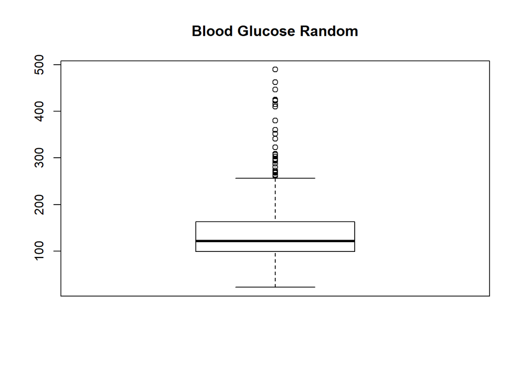

```r
#Transformación a tipo numeric
data$bgr<-as.character(data$bgr)#Conversion a caracter
data$bgr<-as.numeric(gsub(",",".",data$bgr))#Se corrige posibles inconsistencias en el separador decimal y se tranforma en numeric.
id_bgr<-which(is.na(data$bgr))
data[id_bgr,]$bgr<-NA
boxplot(data$bgr,main='Blood Glucose Random')
```

- **bu**

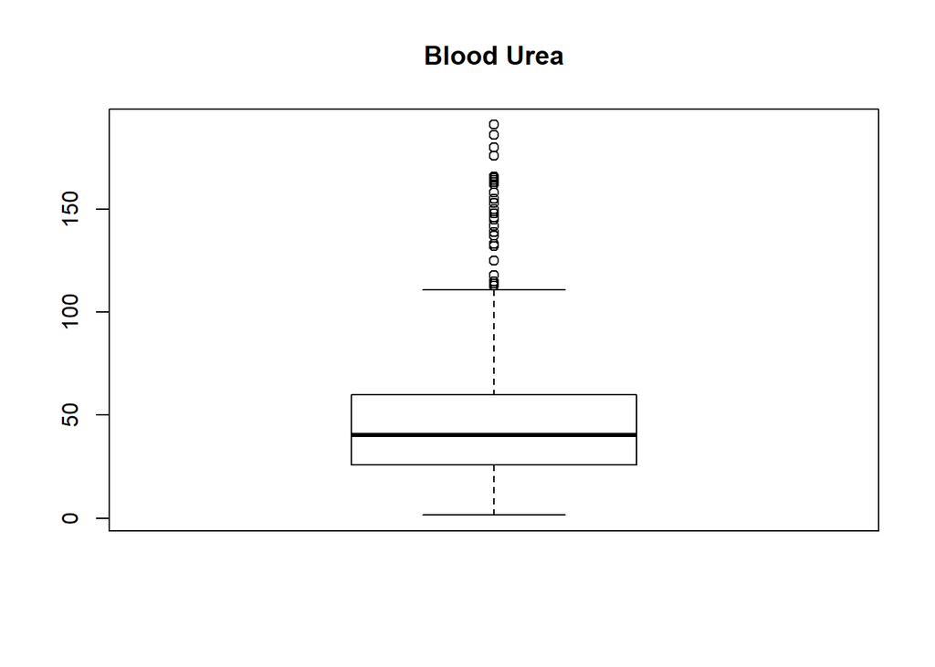

```r
#Transformación a tipo numeric
data$bu<-as.character(data$bu)#Conversion a caracter
data$bu<-as.numeric(gsub(",",".",data$bu))#Se corrige posibles inconsistencias en el separador decimal y se tranforma en numeric.
id_bu<-which(is.na(data$bu)|data$bu>200)
data[id_bu,]$bu<-NA
boxplot(data$bu,main='Blood Urea')
```

- **sc**

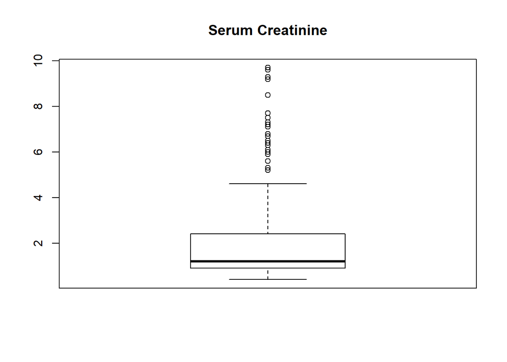

```r
#Transformación a tipo numeric
data$sc<-as.character(data$sc)#Conversion a caracter
data$sc<-as.numeric(gsub(",",".",data$sc))#Se corrige posibles inconsistencias en el separador decimal y se tranforma en numeric.
id_sc<-which(is.na(data$sc)|data$sc>10)#Reemplazarmos los valores de creatinina mayores que 10.
data[id_sc,]$sc<-NA
boxplot(data$sc,main='Serum Creatinine')
```

- **sod**

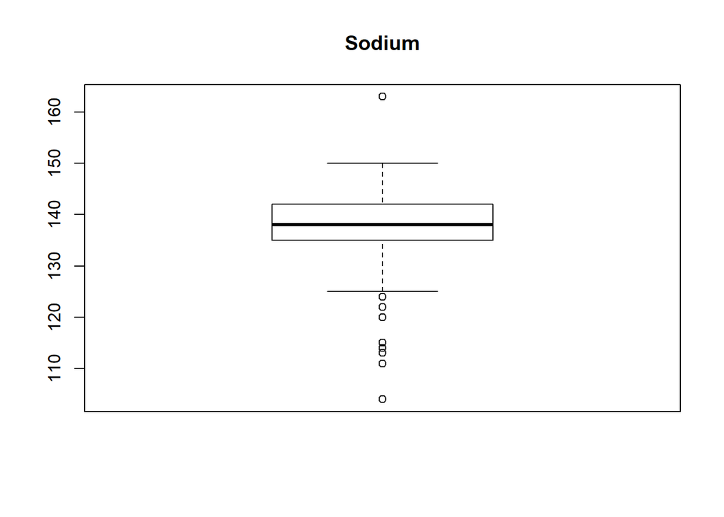

```r
#Transformación a tipo numeric
data$sod<-as.character(data$sod)#Conversion a caracter
data$sod<-as.numeric(gsub(",",".",data$sod))#Se corrige posibles inconsistencias en el separador decimal y se tranforma en numeric.
id_sod<-which(is.na(data$sod)|data$sod<10)
data[id_sod,]$sod<-NA
boxplot(data$sod,main='Sodium')
```

- **pot**

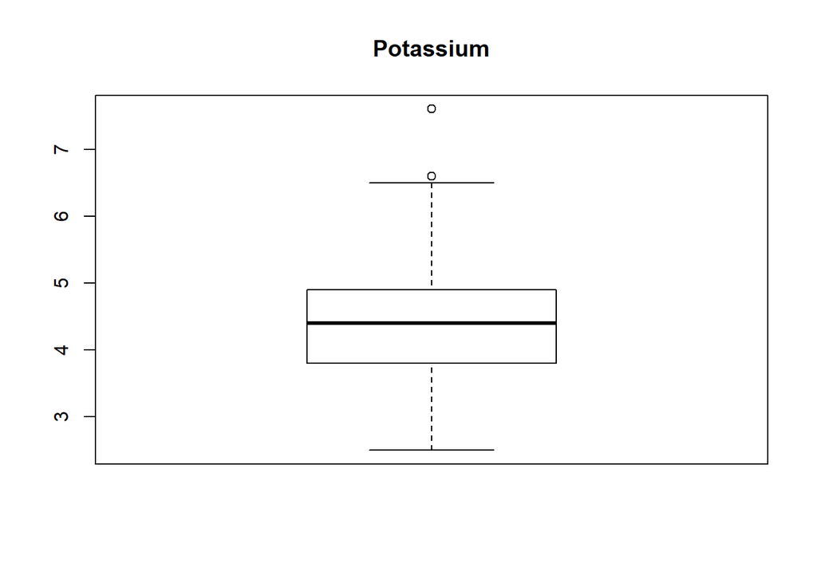

```r
#Transformación a tipo numeric
data$pot<-as.character(data$pot)#Conversion a caracter
data$pot<-as.numeric(gsub(",",".",data$pot))#Se corrige posibles inconsistencias en el separador decimal y se tranforma en numeric.
id_pot<-which(is.na(data$pot)|data$pot>10)
data[id_pot,]$pot<-NA
boxplot(data$pot,main='Potassium')
```

- **hemo**

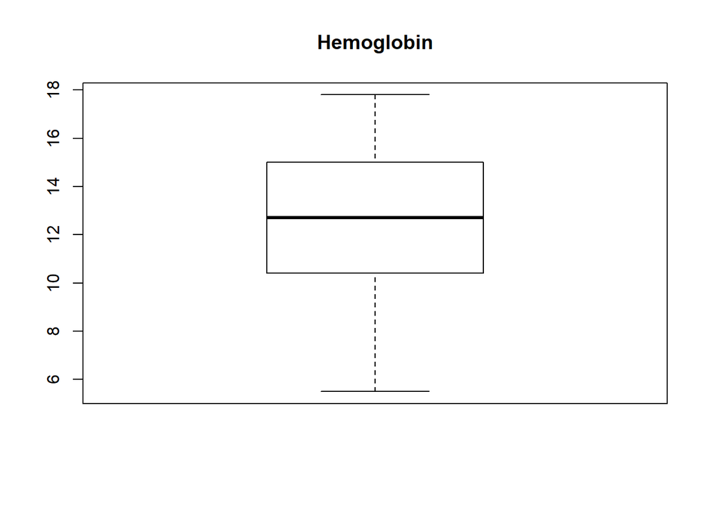

```r
#Transformación a tipo numeric
data$hemo<-as.character(data$hemo)#Conversion a caracter
data$hemo<-as.numeric(gsub(",",".",data$hemo))#Se corrige posibles inconsistencias en el separador decimal y se tranforma en numeric.
id_hemo<-which(is.na(data$hemo)|data$hemo<5)
data[id_hemo,]$hemo<-NA
boxplot(data$hemo,main='Hemoglobin')
```

- **pcv**

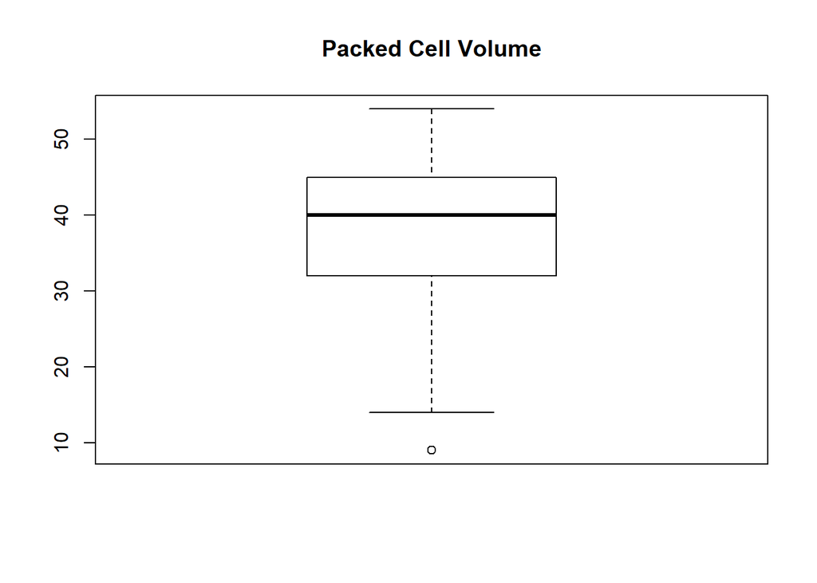

```r
#Transformación a tipo numeric
data$pcv<-as.character(data$pcv)#Conversion a caracter
data$pcv<-suppressWarnings(as.numeric(gsub(",",".",data$pcv)))#Se corrige posibles inconsistencias en el separador decimal y se tranforma en numeric.

id_pcv<-which(is.na(data$pcv))
data[id_pcv,]$pcv<-NA
boxplot(data$pcv,main='Packed Cell Volume')
```

- **wc**

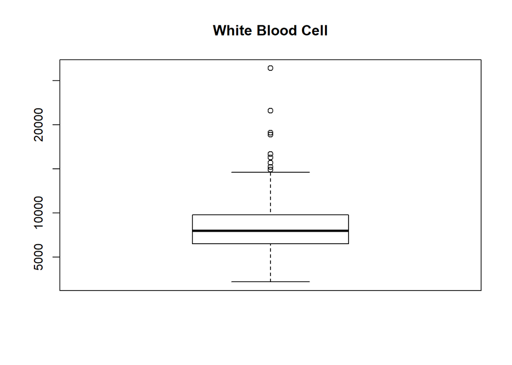

```r
#Transformación a tipo numeric
data$wc<-as.character(data$wc)#Conversion a caracter
data$wc<-suppressWarnings(as.numeric(gsub(",",".",data$wc)))#Se corrige posibles inconsistencias en el separador decimal y se tranforma en numeric.

id_wc<-which(is.na(data$wc))
data[id_wc,]$wc<-NA
boxplot(data$wc,main='White Blood Cell')
```

- **rc**

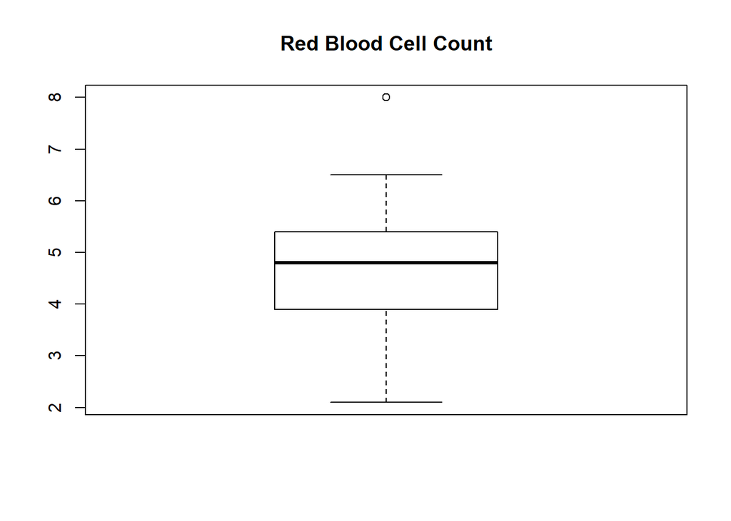

```r
#Transformación a tipo numeric
data$rc<-as.character(data$rc)#Conversion a caracter
data$rc<-suppressWarnings(as.numeric(gsub(",",".",data$rc)))#Se corrige posibles inconsistencias en el separador decimal y se tranforma en numeric.

id_rc<-which(is.na(data$rc))
data[id_rc,]$rc<-NA
boxplot(data$rc,main='Red Blood Cell Count')
```

- **htn**

```r
#Sustituimos los valores vacíos por la categoría más frecuente

frecuencias8 <- data.frame(table(data$htn))
moda8<- frecuencias8[which.max(frecuencias8$Freq),1]

data$htn[data$htn=='']<-moda8
table(data$htn)
```

```
##
##      no yes
##   0 253 147
```

- **dm**

```r
#Sustituimos los valores vacíos por la categoría más frecuente

frecuencias9 <- data.frame(table(data$dm))
moda9<- frecuencias9[which.max(frecuencias9$Freq),1]

data$dm[(data$dm=='')]<-moda9
#Corregimos las categorías "\tno", "\tyes", " yes" por las correctas
data$dm[data$dm=="\tno"]<-'no'
data$dm[data$dm=="\tyes"]<-'yes'
data$dm[data$dm==" yes"]<-'yes'
```

- **cad**

```r
#Sustituimos los valores vacíos por la categoría más frecuente

frecuencias10<- data.frame(table(data$cad))
moda10<- frecuencias10[which.max(frecuencias10$Freq),1]
#Corregimos las categorías "\tno", " yes" por las correctas
data$cad[(data$cad=='')]<-moda10
data$cad[data$cad=="\tno"]<-'no'
data$cad[data$cad==" yes"]<-'yes'
```

- **appet**

```r
#Sustituimos los valores vacíos por la categoría más frecuente

frecuencias11<- data.frame(table(data$appet))
moda11<- frecuencias11[which.max(frecuencias11$Freq),1]

data$appet[(data$appet=='')]<-moda11
```

- **pe**

```r
#Sustituimos los valores vacíos por la categoría más frecuente

frecuencias12<- data.frame(table(data$pe))
moda12<- frecuencias12[which.max(frecuencias12$Freq),1]

data$pe[(data$pe=='')]<-moda12
```

- **ane**

```r
#Sustituimos los valores vacíos por la categoría más frecuente

frecuencias13<- data.frame(table(data$ane))
moda13<- frecuencias13[which.max(frecuencias13$Freq),1]

data$ane[(data$ane=='')]<-moda13
```

- **classification**

```r
#Sustituimos los valores vacíos por la categoría más frecuente

frecuencias14<- data.frame(table(data$classification))
moda14<- frecuencias14[which.max(frecuencias14$Freq),1]

data$classification[(data$classification=='')]<-moda14
#Corregimos las categoría 'ckd\t' por la correcta.
data$classification[(data$classification=='ckd\t')]<-'ckd'
```

Ademas, hemos tratado los valores extremos del siguiente modo:

- Blood Pressure:Valores posibles en pacientes con hipertensión arterial. Los conservamos
- Blood Glucose: Valores compatibles con pacientes diabéticos.Conservamos
- Creatinine: Reemplazarmos los registros con una creatinina superior a 10 (pacientes con IRC en estadío 5, estando en diálisis, no suelen tener mas de 8-10 unidades)
- Sodium:Reemplazarmos el valor 4.5 teniendo en cuenta que el rango normal de los valores de sodio son (135-145 unidades)
- Potassium :Reemplazaremos 37,47 teniendo en cuenta que el rango normal de los valores de potasio son (3.4-5.5 unidades)
- Hemoglobin: Reemplazamos. Valor no compatible.
- White Blood Cell:valores compatibles con infección o incluso con enfermedad subyacente. Conservamos.
- Red Blood Cell Count:Valor compatible con enfermedad (Hepaticas con Ferritina alta).Mantenemos.
- Blood Urea: Reemplazamos a partir de 200. Valores >200 compatibles con IRC muy muy avanzada.

**Imputamos las variables numéricas con los tres vecinos más cercanos.**

```r
#Imputación para la variable bp
#("age","bp","bgr","bu","sc","sod","pot","hemo","pcv","wc","rc")
#x<-data[,idQuantitative]
#knnOutut<-kNN(x,variable=c('bp'),k=3,dist_var=c("age","bgr","bu","sc","sod","pot","hemo","pcv","wc","rc"))
#knnOutut[knnOutut$bp_imp==TRUE,]
#data[id_bp,]$bp<-knnOutut[knnOutut$bp_imp==TRUE,]$bp
x<-data[,idQuantitative]#Datos numéricos del dataset

#Imputación para todas las variables. Asignamos los valores al dataframe tras la imputación.
knnOutut_total<-kNN(x,variable=c("age","bp","bgr","bu","sc","sod","pot","hemo","pcv","wc","rc"),k=3,dist_var=c("age","bp","bgr","bu","sc","sod","pot","hemo","pcv","wc","rc"))
head(knnOutut_total)
```

```
##   age bp bgr bu  sc sod pot hemo pcv   wc  rc age_imp bp_imp bgr_imp bu_imp
## 1  48 80 121 36 1.2 140 5.0 15.4  44 7800 5.2   FALSE  FALSE   FALSE  FALSE
## 2   7 50  92 18 0.8 141 4.1 11.3  38 6000 4.7   FALSE  FALSE    TRUE  FALSE
## 3  62 80 423 53 1.8 134 4.3  9.6  31 7500 4.1   FALSE  FALSE   FALSE  FALSE
## 4  48 70 117 56 3.8 111 2.5 11.2  32 6700 3.9   FALSE  FALSE   FALSE  FALSE
## 5  51 80 106 26 1.4 141 4.2 11.6  35 7300 4.6   FALSE  FALSE   FALSE  FALSE
## 6  60 90  74 25 1.1 142 3.2 12.2  39 7800 4.4   FALSE  FALSE   FALSE  FALSE
##   sc_imp sod_imp pot_imp hemo_imp pcv_imp wc_imp rc_imp
## 1  FALSE    TRUE    TRUE    FALSE   FALSE  FALSE  FALSE
## 2  FALSE    TRUE    TRUE    FALSE   FALSE  FALSE   TRUE
## 3  FALSE    TRUE    TRUE    FALSE   FALSE  FALSE   TRUE
## 4  FALSE   FALSE   FALSE    FALSE   FALSE  FALSE  FALSE
## 5  FALSE    TRUE    TRUE    FALSE   FALSE  FALSE  FALSE
## 6  FALSE   FALSE   FALSE    FALSE   FALSE  FALSE  FALSE
```

```r
data[id_bp,]$bp<-knnOutut_total[knnOutut_total$bp_imp==TRUE,]$bp
data[id_bgr,]$bgr<-knnOutut_total[knnOutut_total$bgr_imp==TRUE,]$bgr
data[id_bu,]$bu<-knnOutut_total[knnOutut_total$bu_imp==TRUE,]$bu
data[id_sc,]$sc<-knnOutut_total[knnOutut_total$sc_imp==TRUE,]$sc
data[id_sod,]$sod<-knnOutut_total[knnOutut_total$sod_imp==TRUE,]$sod
data[id_pot,]$pot<-knnOutut_total[knnOutut_total$pot_imp==TRUE,]$pot
data[id_hemo,]$hemo<-knnOutut_total[knnOutut_total$hemo_imp==TRUE,]$hemo
data[id_pcv,]$pcv<-knnOutut_total[knnOutut_total$pcv_imp==TRUE,]$pcv
data[id_wc,]$wc<-knnOutut_total[knnOutut_total$wc_imp==TRUE,]$wc
data[id_rc,]$rc<-knnOutut_total[knnOutut_total$rc_imp==TRUE,]$rc
```

Comprobemos que todos los valores perdidos han sido imputados:

```r
sum(is.na(data$bp))
```

```
## [1] 0
```

```r
sum(is.na(data$bgr))
```

```
## [1] 0
```

```r
sum(is.na(data$bu))
```

```
## [1] 0
```

```r
sum(is.na(data$sc))
```

```
## [1] 0
```

```r
sum(is.na(data$sod))
```

```
## [1] 0
```

```r
sum(is.na(data$pot))
```

```
## [1] 0
```

```r
sum(is.na(data$hemo))
```

```
## [1] 0
```

```r
sum(is.na(data$pcv))
```

```
## [1] 0
```

```r
sum(is.na(data$wc))
```

```
## [1] 0
```

```r
sum(is.na(data$rc))
```

```
## [1] 0
```

##### *2.Imputación de las variables categóricas con la clase más frecuente.*

- **sg**, se ha cargado como factor correctamente.Sin embargo hay 6 categorías y debería haber 5 (1.005,1.010,1.015,1.020,1.025).Realizamos las transformaciones necesarias. Sustituimos los valores vacíos por la categoría más frecuente.

```r
#Comprobamos las categorías
unique(data$sg)# 6 Categorías
```

```
## [1] 1.02  1.01  1.005 1.015 1.025
## Levels:  1.005 1.01 1.015 1.02 1.025
```

```r
sum(is.na(data$sg)) #No hay 'NA'
```

```
## [1] 0
```

```r
table(data$sg)
```

```
##
##       1.005  1.01 1.015  1.02 1.025
##     0     7    84    75   153    81
```

```r
#Sustituimos los valores vacíos por la categoría más frecuente

frecuencias <- data.frame(table(data$sg))
moda <- frecuencias[which.max(frecuencias$Freq),1]

data$sg[data$sg=='']<-moda
table(data$sg)
```

```
##
##       1.005  1.01 1.015  1.02 1.025
##     0     7    84    75   153    81
```

- **al**, se ha cargado correctamente como factor. Debería tener 6 niveles (0,1,2,3,4,5) , pero obtenemos en un inicio 7.

```r
#Comprobamos las categorías
unique(data$al)# 7 Categorías
```

```
## [1] 1.0 4.0 2.0 3.0 0.0 5.0
## Levels:  0.0 1.0 2.0 3.0 4.0 5.0
```

```r
sum(is.na(data$al)) #No hay 'NA'
```

```
## [1] 0
```

```r
table(data$al)
```

```
##
##     0.0 1.0 2.0 3.0 4.0 5.0
##   0 245  44  43  43  24   1
```

```r
#Sustituimos los valores vacíos por la categoría más frecuente

frecuencias2 <- data.frame(table(data$al))
moda2 <- frecuencias2[which.max(frecuencias2$Freq),1]

data$al[data$al=='']<-moda2
table(data$al)
```

```
##
##     0.0 1.0 2.0 3.0 4.0 5.0
##   0 245  44  43  43  24   1
```

- **su**, se ha cargado correctamente como factor. Debería tener 6 niveles (0,1,2,3,4,5) , pero obtenemos en un inicio 7.

```r
#Comprobamos las categorías
unique(data$su)# 7 Categorías
```

```
## [1] 0.0 3.0 4.0 1.0     2.0 5.0
## Levels:  0.0 1.0 2.0 3.0 4.0 5.0
```

```r
sum(is.na(data$su)) #No hay 'NA'
```

```
## [1] 0
```

```r
table(data$su)
```

```
##
##     0.0 1.0 2.0 3.0 4.0 5.0
##  49 290  13  18  14  13   3
```

```r
#Sustituimos los valores vacíos por la categoría más frecuente

frecuencias3 <- data.frame(table(data$su))
moda3 <- frecuencias3[which.max(frecuencias3$Freq),1]

data$su[data$su=='']<-moda3
table(data$su)
```

```
##
##     0.0 1.0 2.0 3.0 4.0 5.0
##   0 339  13  18  14  13   3
```

- **rbc**, se ha cargado correctamente como factor. Debería tener 2 niveles (normal,abnormal) , pero obtenemos en un inicio 3.

```r
#Comprobamos las categorías
unique(data$rbc)# 3 Categorías
```

```
## [1] normal   abnormal
## Levels:  abnormal normal
```

```r
sum(is.na(data$rbc)) #No hay 'NA'
```

```
## [1] 0
```

```r
table(data$rbc)
```

```
##
##          abnormal   normal
##        0       47      353
```

```r
#Sustituimos los valores vacíos por la categoría más frecuente

frecuencias4 <- data.frame(table(data$rbc))
moda4 <- frecuencias4[which.max(frecuencias4$Freq),1]

data$rbc[data$rbc=='']<-moda4
table(data$rbc)
```

```
##
##          abnormal   normal
##        0       47      353
```

- **pc**, se ha cargado correctamente como factor. Debería tener 2 niveles (normal,abnormal) , pero obtenemos en un inicio 3.

```r
#Comprobamos las categorías
unique(data$pc)# 3 Categorías
```

```
## [1] normal   abnormal
## Levels:  abnormal normal
```

```r
sum(is.na(data$pc)) #No hay 'NA'
```

```
## [1] 0
```

```r
table(data$pc)
```

```
##
##          abnormal   normal
##        0       76      324
```

```r
#Sustituimos los valores vacíos por la categoría más frecuente

frecuencias5 <- data.frame(table(data$pc))
moda5<- frecuencias5[which.max(frecuencias5$Freq),1]

data$pc[data$pc=='']<-moda5
table(data$pc)
```

```
##
##          abnormal   normal
##        0       76      324
```

- **pcc**, se ha cargado correctamente como factor. Debería tener 2 niveles (present,notpresent) , pero obtenemos en un inicio 3.

```r
#Comprobamos las categorías
unique(data$pcc)# 3 Categorías
```

```
## [1] notpresent present
## Levels:  notpresent present
```

```r
sum(is.na(data$pcc)) #No hay 'NA'
```

```
## [1] 0
```

```r
table(data$pcc)
```

```
##
##            notpresent    present
##          0        358         42
```

```r
#Sustituimos los valores vacíos por la categoría más frecuente

frecuencias6 <- data.frame(table(data$pcc))
moda6<- frecuencias6[which.max(frecuencias6$Freq),1]

data$pcc[data$pcc=='']<-moda6
table(data$pcc)
```

```
##
##            notpresent    present
##          0        358         42
```

- **ba**, se ha cargado correctamente como factor. Debería tener 2 niveles (present,notpresent) , pero obtenemos en un inicio 3.

```r
#Comprobamos las categorías
unique(data$ba)# 3 Categorías
```

```
## [1] notpresent present
## Levels:  notpresent present
```

```r
sum(is.na(data$ba)) #No hay 'NA'
```

```
## [1] 0
```

```r
table(data$ba)
```

```
##
##            notpresent    present
##          0        378         22
```

```r
#Sustituimos los valores vacíos por la categoría más frecuente

frecuencias7 <- data.frame(table(data$ba))
moda7<- frecuencias7[which.max(frecuencias7$Freq),1]

data$ba[data$ba=='']<-moda7
table(data$ba)
```

```
##
##            notpresent    present
##          0        378         22
```

- **htn**, se ha cargado correctamente como factor. Debería tener 2 niveles (yes,no) , pero obtenemos en un inicio 3.

```r
#Comprobamos las categorías
unique(data$htn)# 3 Categorías
```

```
## [1] yes no
## Levels:  no yes
```

```r
sum(is.na(data$htn)) #No hay 'NA'
```

```
## [1] 0
```

```r
table(data$htn)
```

```
##
##      no yes
##   0 253 147
```

```r
#Sustituimos los valores vacíos por la categoría más frecuente

frecuencias8 <- data.frame(table(data$htn))
moda8<- frecuencias8[which.max(frecuencias8$Freq),1]

data$htn[data$htn=='']<-moda8
table(data$htn)
```

```
##
##      no yes
##   0 253 147
```

```r
#Comprobamos las categorías
unique(data$dm)# 5 Categorías
```

```
## [1] yes no
## Levels:   yes \tno \tyes no yes
```

```r
sum(is.na(data$dm)) #No hay 'NA'
```

```
## [1] 0
```

```r
table(data$dm)
```

```
##
##       yes  \tno \tyes   no  yes
##    0    0    0    0  263  137
```

```r
#Sustituimos los valores vacíos por la categoría más frecuente

frecuencias9 <- data.frame(table(data$dm))
moda9<- frecuencias9[which.max(frecuencias9$Freq),1]

data$dm[(data$dm=='')]<-moda9
data$dm[data$dm=="\tno"]<-'no'
data$dm[data$dm=="\tyes"]<-'yes'
data$dm[data$dm==" yes"]<-'yes'
table(data$dm)
```

```
##
##       yes  \tno \tyes   no  yes
##    0    0    0    0  263  137
```

- **cad**, se ha cargado correctamente como factor. Debería tener 2 niveles (yes,no) , pero obtenemos en un inicio 4.

```r
#Comprobamos las categorías
unique(data$cad)# 4 Categorías
```

```
## [1] no  yes
## Levels:  \tno no yes
```

```r
sum(is.na(data$cad)) #No hay 'NA'
```

```
## [1] 0
```

```r
table(data$cad)
```

```
##
##     \tno  no yes
##   0   0 366  34
```

```r
#Sustituimos los valores vacíos por la categoría más frecuente

frecuencias10<- data.frame(table(data$cad))
moda10<- frecuencias10[which.max(frecuencias10$Freq),1]

data$cad[(data$cad=='')]<-moda10
data$cad[data$cad=="\tno"]<-'no'
data$cad[data$cad==" yes"]<-'yes'
table(data$cad)
```

```
##
##     \tno  no yes
##   0   0 366  34
```

- **appet**, se ha cargado correctamente como factor. Debería tener 2 niveles (good,poor) , pero obtenemos en un inicio 3.

```r
#Comprobamos las categorías
unique(data$appet)# 3 Categorías
```

```
## [1] good poor
## Levels:  good poor
```

```r
sum(is.na(data$appet)) #No hay 'NA'
```

```
## [1] 0
```

```r
table(data$appet)
```

```
##
##      good poor
##    0  318   82
```

```r
#Sustituimos los valores vacíos por la categoría más frecuente

frecuencias11<- data.frame(table(data$appet))
moda11<- frecuencias11[which.max(frecuencias11$Freq),1]

data$appet[(data$appet=='')]<-moda11

table(data$appet)
```

```
##
##      good poor
##    0  318   82
```

- **pe**, se ha cargado correctamente como factor. Debería tener 2 niveles (yes,no) , pero obtenemos en un inicio 3.

```r
#Comprobamos las categorías
unique(data$pe)# 3 Categorías
```

```
## [1] no  yes
## Levels:  no yes
```

```r
sum(is.na(data$pe)) #No hay 'NA'
```

```
## [1] 0
```

```r
table(data$pe)
```

```
##
##      no yes
##   0 324  76
```

```r
#Sustituimos los valores vacíos por la categoría más frecuente

frecuencias12<- data.frame(table(data$pe))
moda12<- frecuencias12[which.max(frecuencias12$Freq),1]

data$pe[(data$pe=='')]<-moda12

table(data$pe)
```

```
##
##      no yes
##   0 324  76
```

- **ane**, se ha cargado correctamente como factor. Debería tener 2 niveles (yes,no) , pero obtenemos en un inicio 3.

```r
#Comprobamos las categorías
unique(data$ane)# 3 Categorías
```

```
## [1] no  yes
## Levels:  no yes
```

```r
sum(is.na(data$ane)) #No hay 'NA'
```

```
## [1] 0
```

```r
table(data$ane)
```

```
##
##      no yes
##   0 340  60
```

```r
#Sustituimos los valores vacíos por la categoría más frecuente

frecuencias13<- data.frame(table(data$ane))
moda13<- frecuencias13[which.max(frecuencias13$Freq),1]

data$ane[(data$ane=='')]<-moda13

table(data$ane)
```

```
##
##      no yes
##   0 340  60
```

- **classification**, se ha cargado correctamente como factor. Debería tener 2 niveles (ckd,notckd) , pero obtenemos en un inicio 3.

```r
#Comprobamos las categorías
unique(data$classification)# 3 Categorías
```

```
## [1] ckd    notckd
## Levels: ckd ckd\t notckd
```

```r
sum(is.na(data$classification)) #No hay 'NA'
```

```
## [1] 0
```

```r
table(data$classification)
```

```
##
##    ckd   ckd\t notckd
##    250      0    150
```

```r
#Sustituimos los valores vacíos por la categoría más frecuente

frecuencias14<- data.frame(table(data$classification))
moda14<- frecuencias14[which.max(frecuencias14$Freq),1]

data$classification[(data$classification=='')]<-moda14
data$classification[(data$classification=='ckd\t')]<-'ckd'
table(data$classification)
```

```
##
##    ckd   ckd\t notckd
##    250      0    150
```

Eliminamos las categorías no usadas de cada atributo y comprobemos si la estructura de los datos, es la adecuada después de la transformación:

```r
data<-droplevels.data.frame(data)
str(data)
```

```
## 'data.frame':    400 obs. of  26 variables:
##  $ id            : int  0 1 2 3 4 5 6 7 8 9 ...
##  $ age           : num  48 7 62 48 51 60 68 24 52 53 ...
##  $ bp            : num  80 50 80 70 80 90 70 80 100 90 ...
##  $ sg            : Factor w/ 5 levels "1.005","1.01",..: 4 4 2 1 2 3 2 3 3 4 ...
##  $ al            : Factor w/ 6 levels "0.0","1.0","2.0",..: 2 5 3 5 3 4 1 3 4 3 ...
##  $ su            : Factor w/ 6 levels "0.0","1.0","2.0",..: 1 1 4 1 1 1 1 5 1 1 ...
##  $ rbc           : Factor w/ 2 levels "abnormal","normal": 2 2 2 2 2 2 2 2 2 1 ...
##  $ pc            : Factor w/ 2 levels "abnormal","normal": 2 2 2 1 2 2 2 1 1 1 ...
##  $ pcc           : Factor w/ 2 levels "notpresent","present": 1 1 1 2 1 1 1 1 2 2 ...
##  $ ba            : Factor w/ 2 levels "notpresent","present": 1 1 1 1 1 1 1 1 1 1 ...
##  $ bgr           : num  121 92 423 117 106 74 100 410 138 70 ...
##  $ bu            : num  36 18 53 56 26 25 54 31 60 107 ...
##  $ sc            : num  1.2 0.8 1.8 3.8 1.4 1.1 1.8 1.1 1.9 7.2 ...
##  $ sod           : num  140 141 134 111 141 142 104 142 136 114 ...
##  $ pot           : num  5 4.1 4.3 2.5 4.2 3.2 4 4.4 4.9 3.7 ...
##  $ hemo          : num  15.4 11.3 9.6 11.2 11.6 12.2 12.4 12.4 10.8 9.5 ...
##  $ pcv           : num  44 38 31 32 35 39 36 44 33 29 ...
##  $ wc            : num  7800 6000 7500 6700 7300 7800 6000 6900 9600 12100 ...
##  $ rc            : num  5.2 4.7 4.1 3.9 4.6 4.4 3.9 5 4 3.7 ...
##  $ htn           : Factor w/ 2 levels "no","yes": 2 1 1 2 1 2 1 1 2 2 ...
##  $ dm            : Factor w/ 2 levels "no","yes": 2 1 2 1 1 2 1 2 2 2 ...
##  $ cad           : Factor w/ 2 levels "no","yes": 1 1 1 1 1 1 1 1 1 1 ...
##  $ appet         : Factor w/ 2 levels "good","poor": 1 1 2 2 1 1 1 1 1 2 ...
##  $ pe            : Factor w/ 2 levels "no","yes": 1 1 1 2 1 2 1 2 1 1 ...
##  $ ane           : Factor w/ 2 levels "no","yes": 1 1 2 2 1 1 1 1 2 2 ...
##  $ classification: Factor w/ 2 levels "ckd","notckd": 1 1 1 1 1 1 1 1 1 1 ...
```

```r
write.csv(data, file="kidney_disease_clean_3.csv", row.names = FALSE)
```